# Experiments with whitening

```r
library(tidyverse)
library(magrittr)
library(glue)
library(cytominergallery)
```

Load the BBBC021 dataset

```r
profiles <-
  readr::read_csv(system.file("extdata", "ljosa_jbiomolscreen_2013_per_well_mean.csv",
                package = "cytominergallery"))

moa <-
  readr::read_csv(system.file("extdata", "BBBC021_v1_moa.csv",
                              package = "cytominergallery")) %>%
  rename(Image_Metadata_Compound = compound,
                Image_Metadata_Concentration = concentration,
                Image_Metadata_MoA = moa
  )

metadata <-
  readr::read_csv(system.file("extdata", "BBBC021_v1_image.csv",
                              package = "cytominergallery")) %>%
  rename(Image_Metadata_Plate = Image_Metadata_Plate_DAPI,
                Image_Metadata_Well = Image_Metadata_Well_DAPI
  ) %>%
  select(matches("^Image_Metadata")) %>%
  inner_join(moa) %>%
  distinct()

profiles %<>%
  inner_join(metadata)

profiles %<>%
  separate(col = Image_Metadata_Plate, into = c("Image_Metadata_Batch", "Image_Metadata_Plate"), remove = TRUE)

variables <-
  colnames(profiles) %>%
  str_subset("^Nuclei_|^Cells_|^Cytoplasm_")
```

Select variables based on variable thresholding (remove near-zero variance variables) and correlation thresholding (select a subset of variables that are not highly correlated)

```r
futile.logger::flog.threshold(futile.logger::ERROR)
```

```r
variables <-
  colnames(profiles) %>%
  str_subset("^Nuclei_|^Cells_|^Cytoplasm_")

profiles %<>%
  cytominer::variable_select(
  variables = variables,
  sample = profiles %>% filter(Image_Metadata_Compound == "DMSO"),
  operation = "variance_threshold"
  )

profiles %<>% na.omit()

variables <-
  colnames(profiles) %>%
  str_subset("^Nuclei_|^Cells_|^Cytoplasm_")

profiles %<>%
  cytominer::variable_select(
  variables = variables,
  sample = profiles,
  operation = "correlation_threshold"
  )

variables <-
  colnames(profiles) %>%
  str_subset("^Nuclei_|^Cells_|^Cytoplasm_")

n_variables_original <-  length(variables)
```

Define function to get variance of whitened data matrix

```r
get_variance <- function(profiles) {
  cov(
    profiles %>%
      filter(Image_Metadata_Compound == "DMSO") %>%
      select(matches("^PC")) %>%
      as.matrix()
  ) %>%
    diag() %>%
    t() %>%
    as.data.frame() %>%
    gather(dimension, value) %>%
    mutate(dimension = str_replace(dimension, "PC", "")) %>%
    mutate(dimension = as.integer(dimension))
}
```

Whiten the entire dataset using DMSO distribution as a reference

```r
# specify regularization parameter for whitening transformation

whiten_global_alpha_neg_log_10 <- 1

whiten_global_alpha <- 10**(-whiten_global_alpha_neg_log_10)

profiles_global_whitened <-
  profiles %>%
  cytominer::whiten(colnames(profiles) %>%  str_subset("^Nuclei_|^Cells_|^Cytoplasm_"),
                    profiles %>% filter(Image_Metadata_Compound == "DMSO"),
                    whiten_global_alpha)
```

Calculate variance of each dimension of whitened data

```r
variance_global <-  get_variance(profiles_global_whitened)
```

Estimate variance of each dimension of whitened data as:
$$\hat{\sigma_i} = \frac{\sigma_i}{\sigma_i + \epsilon}$$

```r
estimated_whitened_variance <-
  profiles %>%
  filter(Image_Metadata_Compound == "DMSO") %>%
  select(matches("^Nuclei_|^Cells_|^Cytoplasm_")) %>%
  as.matrix() %>%
  cov() %>%
  eigen(only.values = TRUE) %>%
  extract("values") %>%
  as.data.frame() %>%
  rename(variance = values) %>%
  mutate(dimension = 1:n()) %>%
  mutate(estimated_whitened_variance = variance / (variance + whiten_global_alpha)) %>%
  select(dimension, estimated_whitened_variance)
```

Are the estimated and real variances the same?

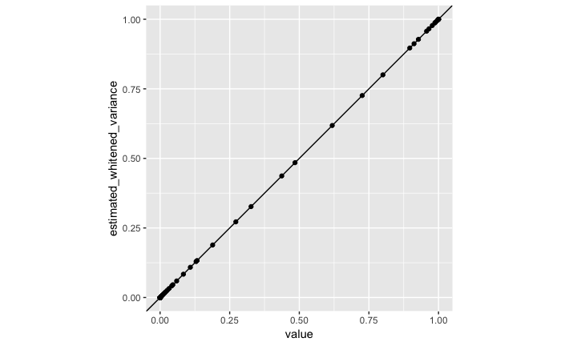

```r
inner_join(estimated_whitened_variance,
           variance_global, by = c("dimension")) %>%
  ggplot(aes(value, estimated_whitened_variance)) +
  geom_point() +
  geom_abline(slope = 1) +
  xlim(c(0, 1)) +
  ylim(c(0, 1)) +
  coord_equal()
```

Plot the variances of each dimension of the whitened data.

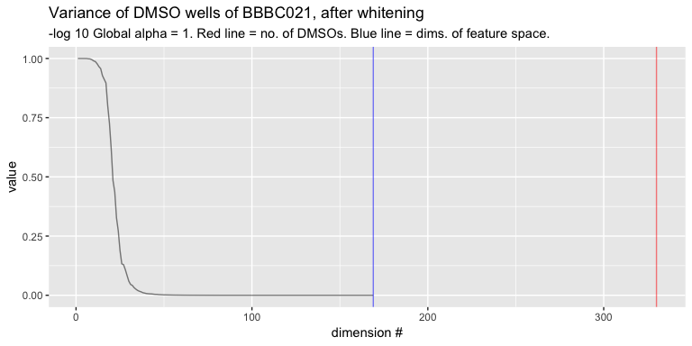

```r
n_dmso <-
  profiles_global_whitened %>%
  filter(Image_Metadata_Compound == "DMSO") %>%
  nrow()

p <-
  ggplot(variance_global,
       aes(dimension, value)) +
  geom_line(alpha = 0.5) +
  geom_vline(aes(xintercept = n_dmso), color = "red", alpha = 0.5) +
  geom_vline(aes(xintercept = n_variables_original), color = "blue", alpha = 0.5) +
  ylim(c(0, 1)) +
  xlab("dimension #") +
  ggtitle("Variance of DMSO wells of BBBC021, after whitening",
          subtitle = glue("-log 10 Global alpha = {whiten_global_alpha_neg_log_10}. Red line = no. of DMSOs. Blue line = dims. of feature space."))

p
```

```r
ggsave(glue("variance_{whiten_global_alpha_neg_log_10}.png"), p, width = 8, height = 4)
```

Perform batch-wise whitening Calculate variance of each dimension of whitened data, per batch Plot the variances of each dimension of the whitened data, per batch

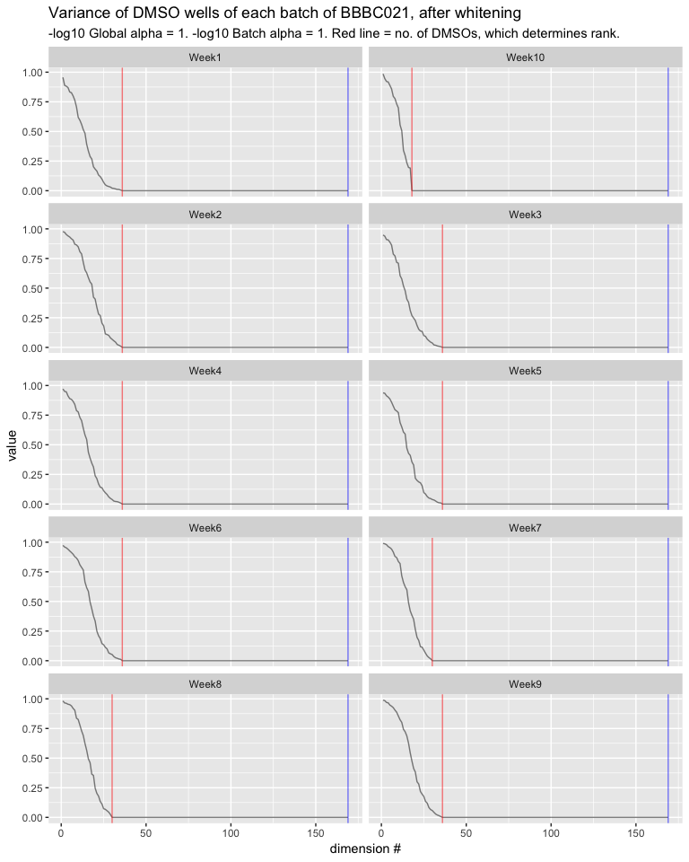

```r
strata <- "Image_Metadata_Batch"

whiten_batch_alpha_neg_log_10 <- 1

whiten_batch_alpha <- 10**(-whiten_batch_alpha_neg_log_10)

population <- profiles_global_whitened

sample <- profiles_global_whitened %>%
  filter(Image_Metadata_Compound == "DMSO")

variables <-
  colnames(profiles_global_whitened) %>%
  str_subset("^PC")

groups <-
  profiles_global_whitened %>%
  dplyr::select_(.dots = strata) %>%
  dplyr::distinct() %>%
  dplyr::collect()

profiles_batch_whitened <-

  Reduce(dplyr::union_all,
         Map(
           f = function(group) {
             stratum <-
               sample %>%
               dplyr::inner_join(y = group,
                                 by = names(group),
                                 copy = TRUE)

             population %>%
               dplyr::inner_join(y = group, by = names(group), copy = TRUE)

             whitened <-
               population %>%
               dplyr::inner_join(y = group,
                                 by = names(group),
                                 copy = TRUE) %>%
               cytominer::whiten(variables, stratum, whiten_batch_alpha)

             whitened
           },
           split(x = groups, f = seq(nrow(groups)))
         ))

# Calculate variance of each dimension of whitened data, per batch

variance <-
  profiles_batch_whitened %>%
  group_by(Image_Metadata_Batch) %>%
  nest() %>%
  mutate(variances = map(data, get_variance)) %>%
  ungroup() %>%
  unnest(variances)

# Plot the variances of each dimension of the whitened data, per batch

p <-
  ggplot(variance,
       aes(dimension, value)) +
  geom_line(alpha = 0.5) +
  geom_vline(data =
               profiles %>%
               filter(Image_Metadata_Compound == "DMSO") %>%
               group_by(Image_Metadata_Batch) %>%
               tally(),
             aes(xintercept = n), color = "red", alpha = 0.5) +
  geom_vline(aes(xintercept = length(variables_original)), color = "blue", alpha = 0.5) +
  facet_wrap(~Image_Metadata_Batch, ncol = 2) +
  xlab("dimension #") +
  ggtitle("Variance of DMSO wells of each batch of BBBC021, after whitening",
          subtitle =
            glue("-log10 Global alpha = {whiten_global_alpha_neg_log_10}. -log10 Batch alpha = {whiten_batch_alpha_neg_log_10}. Red line = no. of DMSOs, which determines rank."))

p
```

```r
ggsave(glue("variance_{whiten_global_alpha_neg_log_10}_{whiten_batch_alpha_neg_log_10}.png"),
       p, width = 8, height = 10)
```

In all, - whitening makes sense when the covariance matrix is full rank, but should not be used otherwise. - we almost never have enough DMSOs to do whitening per batch, given the dimensionality of the feature space. - regularization can’t help with fixing the problem of rank deficiency